# TUT2 - Modelos de regressão são melhores que a média?

Henrique Gomide

2017-08-19

## Motivação

Olá pessoal!

No tutorial anterior, vimos que a média é um indicador limitado para mitar no cartola. Vamos tentar neste tutorial, usar outros modelos e reduzir o risco na tomada de decisão. Começaremos de forma básica, com um modelo de regressão linear. O número a ser batido aqui é RMSE = 4.171413 (lembrando: valores menores são melhores).

[figure not shown]

Este tutorial também é dedicado a *iniciantes* do R e análise de dados.

### Pacotes

Iremos usar o [Caret](http://caret.r-forge.r-project.org) pacote do R que facilita horrores o desenvolvimento de modelos preditivos. Existem inúmeros tutoriais sobre o pacote, além disso até [artigo científico](https://www.jstatsoft.org/article/view/v028i05) publicado no Jounal of Statistical Software.

### Banco de dados

```r
# Carregar banco de dados
cartola <- read.csv("../../db/cartola_aggregated.csv", stringsAsFactors = FALSE)
```

## Plano de Análise

1. Segmentar o banco de dados
2. Desenvolver diferentes modelos de regressão
3. Comparar o desempenho destes modelos com nosso Benchmark - a média.

## Análise

### Segmentar o banco de dados

```r
# Segmentar banco de dados
treino <- cartola %>%
  filter(!(Rodada == 20 & ano == 2017))

validacao <- cartola %>%
  filter(Rodada == 20 & ano == 2017)

# Selecionar somente algumas variáveis
variaveis <- c("AtletaID", "variable", "Posicao", "Pontos", "PontosMedia", "ClubeID")

treino <- treino[, variaveis]
validacao <-  validacao[, variaveis]

# Controles para os modelos
## Regression Models
ctrl <- trainControl(method = "repeatedcv", number = 10, repeats = 1, allowParallel = TRUE, verboseIter = TRUE)
## Random Forest
rfGrid <-  expand.grid(mtry = c(10,20,40,80))
```

## Visualizações

Antes de começarmos precisamos conduzir análises exploratórias para termos uma ideia de quais variáveis podem estar ligadas à pontuação do cartola (atletas.pontos_num). Para isso, inspecionaremos as variáveis:

### Times

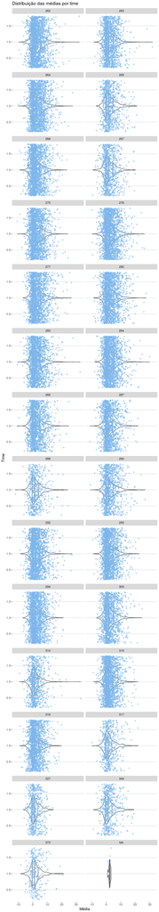

```r
ggplot(data = treino, aes(y = Pontos, x = 1)) +
  geom_violin(draw_quantiles = c(0.25, 0.5, 0.75)) +
  geom_jitter(width = .8, alpha = .5, colour = "#7cb5ec") +
  theme_hc() + facet_wrap(~ClubeID, nrow = 21, shrink = FALSE) + coord_flip() +
  labs(title = "Distribuição das médias por time", x = "Time", y = "Média")
```

### Atletas por posição

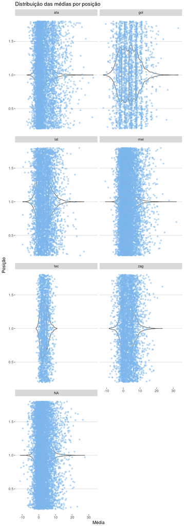

```r
ggplot(data = treino, aes(y = Pontos, x = 1)) +
  geom_violin(draw_quantiles = c(0.25, 0.5, 0.75)) +
  geom_jitter(width = .8, alpha = .5, colour = "#7cb5ec") +
  theme_hc() + facet_wrap(~Posicao, nrow = 6, shrink = FALSE) + coord_flip() +
  labs(title = "Distribuição das médias por posição", x = "Posição", y = "Média")
```

### Times vs. casa

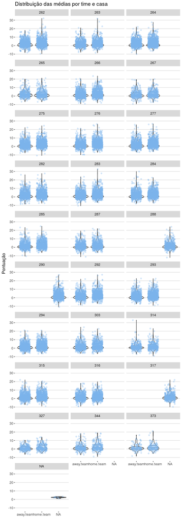

```r
ggplot(data = treino, aes(y = Pontos, factor(variable))) +
  geom_violin(draw_quantiles = c(0.25, 0.5, 0.75)) +
  geom_jitter(width = .3, alpha = .3, colour = "#7cb5ec") +
  theme_hc() + facet_wrap(~ClubeID, ncol = 3) +
  labs(title = "Distribuição das médias por time e casa", x = "", y = "Pontuação")
```

[figure not shown]

```r
ggplot(data = treino, aes(y = Pontos, factor(variable))) +
  geom_violin(draw_quantiles = c(0.25, 0.5, 0.75)) +
  geom_jitter(width = .3, alpha = .3, colour = "#7cb5ec") +
  theme_hc() + facet_wrap(~ ClubeID, ncol = 3) +
  labs(title = "Distribuição das médias por time e casa", x = "", y = "Pontuação")
```

## Modelagem

### Análise de regressão linear simples

```r
predictions <- predict(glmModel_0, newdata = validacao)
postResample(pred = predictions, obs = validacao$Pontos)
```

```
##      RMSE  Rsquared
## 3.6886232 0.2191626
```

### EXtreme Gradient Boosting

```r
boostTree_0  <- train(Pontos ~ variable + Posicao + PontosMedia + ClubeID, data = treino,
                     method="xgbTree", metric = "RMSE", preProcess = c("scale", "center"),
                     trControl = ctrl, na.action = na.omit)
```

```
## Fitting nrounds = 50, max_depth = 2, eta = 0.3, gamma = 0, colsample_bytree = 0.6, min_child_weight = 1, subsample = 1 on full training set
```

```r
predictions_boost <- predict(boostTree_0, newdata = validacao)
postResample(pred = predictions_boost, obs = validacao$Pontos)
```

```
##      RMSE  Rsquared
## 3.7012048 0.2138364
```

## Comentário

Com apenas 4 variáveis fizemos progresso. Baixamos o RMSE em aproximadamente meio ponto, usando qualquer um dos modelos. Do ponto de vista de produção, podemos ficar com o modelo de regressão linear por enquanto. No entanto, ainda temos trabalho diversos pontos de melhora para nossos modelos, entre eles:

1. Separar os scouts de defesa e ataque
2. Criar modelos que predizem os resultados dos jogos
3. Criar modelos que atribuem força ao ataque e a defesa dos times
4. Criar variável sofreu gol no jogo, já que é uma defesa que não leva gols, ganha pontos de recompensa.